```python
from IPython.display import HTML
```

```python
from IPython.display import HTML

HTML('''<script>
code_show=true;
function code_toggle() {
 if (code_show){
 $('div.input').hide();
 } else {
 $('div.input').show();
 }
 code_show = !code_show
}
$( document ).ready(code_toggle);
</script>
The raw code for this IPython notebook is by default hidden for easier reading.
To toggle on/off the raw code, click <a href="javascript:code_toggle()">here</a>.''')
```

The raw code for this IPython notebook is by default hidden for easier reading. To toggle on/off the raw code, click here.

# Simple Logistic Regression in Python

## A project by Vivek Chattopadhyay

```python
import numpy as np
import pandas as pd
import matplotlib.pyplot as plt
import seaborn as sns
%matplotlib inline
```

In this project we will be working with a fake advertising data set, indicating whether or not a particular internet user clicked on an Advertisement on a company website. We will try to create a model that will predict whether or not they will click on an ad based off the features of that user.

This data set contains the following features:

'Daily Time Spent on Site': consumer time on site in minutes

'Age': cutomer age in years

'Area Income': Avg. Income of geographical area of consumer

'Daily Internet Usage': Avg. minutes a day consumer is on the internet

'Ad Topic Line': Headline of the advertisement

'City': City of consumer

'Male': Whether or not consumer was male

'Country': Country of consumer

'Timestamp': Time at which consumer clicked on Ad or closed window

'Clicked on Ad': 0 or 1 indicated clicking on Ad

```python
data = pd.read_csv('advertising.csv')
```

### The Data

```python
data.head(10)
```

|  | Daily Time Spent on Site | Age | Area Income | Daily Internet Usage | Ad Topic Line | City | Male | Country | Timestamp | Clicked on Ad |
| --- | --- | --- | --- | --- | --- | --- | --- | --- | --- | --- |
| 0 | 68.95 | 35 | 61833.90 | 256.09 | Cloned 5thgeneration orchestration | Wrightburgh | 0 | Tunisia | 2016-03-27 00:53:11 | 0 |
| 1 | 80.23 | 31 | 68441.85 | 193.77 | Monitored national standardization | West Jodi | 1 | Nauru | 2016-04-04 01:39:02 | 0 |
| 2 | 69.47 | 26 | 59785.94 | 236.50 | Organic bottom-line service-desk | Davidton | 0 | San Marino | 2016-03-13 20:35:42 | 0 |
| 3 | 74.15 | 29 | 54806.18 | 245.89 | Triple-buffered reciprocal time-frame | West Terrifurt | 1 | Italy | 2016-01-10 02:31:19 | 0 |
| 4 | 68.37 | 35 | 73889.99 | 225.58 | Robust logistical utilization | South Manuel | 0 | Iceland | 2016-06-03 03:36:18 | 0 |
| 5 | 59.99 | 23 | 59761.56 | 226.74 | Sharable client-driven software | Jamieberg | 1 | Norway | 2016-05-19 14:30:17 | 0 |
| 6 | 88.91 | 33 | 53852.85 | 208.36 | Enhanced dedicated support | Brandonstad | 0 | Myanmar | 2016-01-28 20:59:32 | 0 |
| 7 | 66.00 | 48 | 24593.33 | 131.76 | Reactive local challenge | Port Jefferybury | 1 | Australia | 2016-03-07 01:40:15 | 1 |
| 8 | 74.53 | 30 | 68862.00 | 221.51 | Configurable coherent function | West Colin | 1 | Grenada | 2016-04-18 09:33:42 | 0 |
| 9 | 69.88 | 20 | 55642.32 | 183.82 | Mandatory homogeneous architecture | Ramirezton | 1 | Ghana | 2016-07-11 01:42:51 | 0 |

## Descriptive Statistics

```python
data.describe()
```

|  | Daily Time Spent on Site | Age | Area Income | Daily Internet Usage | Male | Clicked on Ad |
| --- | --- | --- | --- | --- | --- | --- |
| count | 1000.000000 | 1000.000000 | 1000.000000 | 1000.000000 | 1000.000000 | 1000.00000 |
| mean | 65.000200 | 36.009000 | 55000.000080 | 180.000100 | 0.481000 | 0.50000 |
| std | 15.853615 | 8.785562 | 13414.634022 | 43.902339 | 0.499889 | 0.50025 |
| min | 32.600000 | 19.000000 | 13996.500000 | 104.780000 | 0.000000 | 0.00000 |
| 25% | 51.360000 | 29.000000 | 47031.802500 | 138.830000 | 0.000000 | 0.00000 |
| 50% | 68.215000 | 35.000000 | 57012.300000 | 183.130000 | 0.000000 | 0.50000 |
| 75% | 78.547500 | 42.000000 | 65470.635000 | 218.792500 | 1.000000 | 1.00000 |
| max | 91.430000 | 61.000000 | 79484.800000 | 269.960000 | 1.000000 | 1.00000 |

## Some Technical Information about the data

```python
data.info()
```

```
<class 'pandas.core.frame.DataFrame'>
RangeIndex: 1000 entries, 0 to 999
Data columns (total 10 columns):
Daily Time Spent on Site    1000 non-null float64
Age                         1000 non-null int64
Area Income                 1000 non-null float64
Daily Internet Usage        1000 non-null float64
Ad Topic Line               1000 non-null object
City                        1000 non-null object
Male                        1000 non-null int64
Country                     1000 non-null object
Timestamp                   1000 non-null datetime64[ns]
Clicked on Ad               1000 non-null int64
dtypes: datetime64[ns](1), float64(3), int64(3), object(3)
memory usage: 78.2+ KB
```

From the above information we ca say that there are 3 categorical variables and 6 continuous variables. We can also see that there is a timestamp object which means we can create new variables based on this timestamp variable.

```python
data['Timestamp'] = pd.to_datetime(data['Timestamp'])
```

```python
data['year'] = data['Timestamp'].apply(lambda x: x.year)
```

```python
data['month'] = data['Timestamp'].apply(lambda x: x.month)
```

```python
data['day'] = data['Timestamp'].apply(lambda x: x.day)
```

```python
data['DOW'] = data['Timestamp'].apply(lambda x: x.dayofweek)
```

```python
data.drop('Timestamp',axis=True,inplace=True)
```

```python
data.info()
```

```
<class 'pandas.core.frame.DataFrame'>
RangeIndex: 1000 entries, 0 to 999
Data columns (total 13 columns):
Daily Time Spent on Site    1000 non-null float64
Age                         1000 non-null int64
Area Income                 1000 non-null float64
Daily Internet Usage        1000 non-null float64
Ad Topic Line               1000 non-null object
City                        1000 non-null object
Male                        1000 non-null int64
Country                     1000 non-null object
Clicked on Ad               1000 non-null int64
year                        1000 non-null int64
month                       1000 non-null int64
day                         1000 non-null int64
DOW                         1000 non-null int64
dtypes: float64(3), int64(7), object(3)
memory usage: 101.6+ KB
```

```python
categoricals = data[['Ad Topic Line','City','Country','year','month','day','DOW']]
```

```python
categoricals.head()
```

|  | Ad Topic Line | City | Country | year | month | day | DOW |
| --- | --- | --- | --- | --- | --- | --- | --- |
| 0 | Cloned 5thgeneration orchestration | Wrightburgh | Tunisia | 2016 | 3 | 27 | 6 |
| 1 | Monitored national standardization | West Jodi | Nauru | 2016 | 4 | 4 | 0 |
| 2 | Organic bottom-line service-desk | Davidton | San Marino | 2016 | 3 | 13 | 6 |
| 3 | Triple-buffered reciprocal time-frame | West Terrifurt | Italy | 2016 | 1 | 10 | 6 |
| 4 | Robust logistical utilization | South Manuel | Iceland | 2016 | 6 | 3 | 4 |

As seen above, 4 new variables are created: Year,Month,Day and DOW.

# Categorical EDA

### Uniques

```python
for i in categoricals.columns:
    print(i)
    print(len(data[i].unique()))
    print('----------------------------------------------------------------------------------------------------------------')
```

```
Ad Topic Line
1000
----------------------------------------------------------------------------------------------------------------
City
969
----------------------------------------------------------------------------------------------------------------
Country
237
----------------------------------------------------------------------------------------------------------------
year
1
----------------------------------------------------------------------------------------------------------------
month
7
----------------------------------------------------------------------------------------------------------------
day
31
----------------------------------------------------------------------------------------------------------------
DOW
7
----------------------------------------------------------------------------------------------------------------
```

**The above topic shows that Ad Topic Line variable has all unique values with no repeataions. Meanwhile, second to that is City followed by Country. Such variables as of now cannot be utilised for specific analysis.**

```python
print('Percentages of Clicked on Site or not!')
print('Percentage of Clicks on Ad: ',len(data[data['Clicked on Ad']==1])/len(data)*100,'%')
print('Percentage of No Clicks on Ad: ',len(data[data['Clicked on Ad']==0])/len(data)*100,'%')
```

```
Percentages of Clicked on Site or not!
Percentage of Clicks on Ad:  50.0 %
Percentage of No Clicks on Ad:  50.0 %
```

**Above shows the percentage of classes of the dependent variable 'Clicked on Ad'. The results shows that there are no class imbalances**

```python
data.groupby('Country')['Clicked on Ad'].count().head(10)
```

```
Country
Afghanistan                                     8
Albania                                         7
Algeria                                         6
American Samoa                                  5
Andorra                                         2
Angola                                          4
Anguilla                                        6
Antarctica (the territory South of 60 deg S)    3
Antigua and Barbuda                             5
Argentina                                       2
Name: Clicked on Ad, dtype: int64
```

```python
data.groupby('month')['Clicked on Ad'].count().head(10)
```

```
month
1    147
2    160
3    156
4    147
5    147
6    142
7    101
Name: Clicked on Ad, dtype: int64
```

```python
data.groupby('DOW')['Clicked on Ad'].count().head(10)
```

```
DOW
0    140
1    122
2    156
3    142
4    155
5    126
6    159
Name: Clicked on Ad, dtype: int64
```

# Continuous EDA

```python
continuous = data[['Daily Time Spent on Site','Age','Area Income','Daily Internet Usage','Male','Clicked on Ad','year','month','day','DOW']]
```

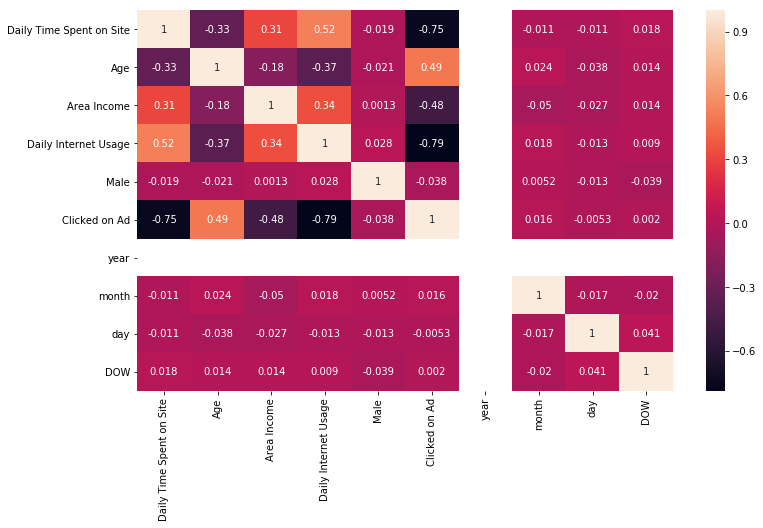

```python
plt.figure(figsize=(12,7))
sns.heatmap(continuous.corr(),annot=True)
```

**Clicked on Ad:**

1) Has a POSITIVE RELATION with Age.

2) Has a NEGATIVE RELATION with Daily Time Spent on Site, Area Income and Daily Internet Usage.

**Age:**

1) Has a POSITIVE RELATION with Clicked on Ad.

2) Has a NEGATIVE RELATION with Daily Time Spent on Site, Area Income and Daily Internet Usage.

**Area Income:**

1) Has a POSITIVE RELATION with Daily Time Spent on Site and Daily Internet Usage.

2) Has a NEGATIVE RELATION with Clicked on Ad and Age.

**Daily Time Spent on Site:**

1) Has a POSITIVE RELATION with Area Income and Daily internet Usage.

2) Has a NEGATIVE RELATION with Age and Clicked on Ad.

**Daily Internet Usage:**

1) Has a POSITIVE RELATION with Daily Time Spent on Site and Area Income.

2) Has a NEGATIVE RELATION with Age and Clicked on Ad.

```
Text(0.5,0,'Age')
```

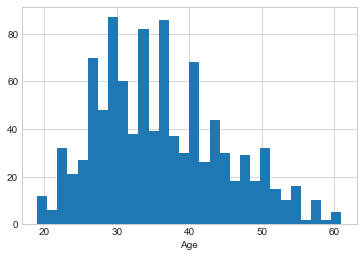

```python
sns.set_style('whitegrid')
data['Age'].hist(bins=30)
plt.xlabel('Age')
```

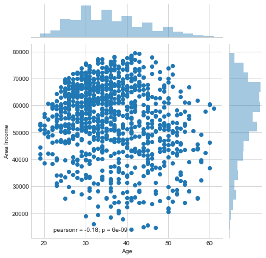

```python
sns.jointplot(x='Age',y='Area Income',data=data)
```

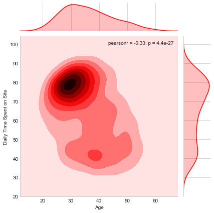

```python
sns.jointplot(x='Age',y='Daily Time Spent on Site',data=data,color='red',kind='kde')
```

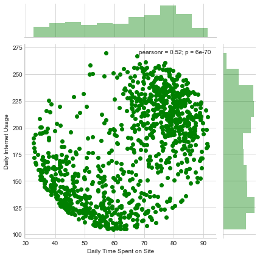

```python
sns.jointplot(x='Daily Time Spent on Site',y='Daily Internet Usage',data=data,color='green')
```

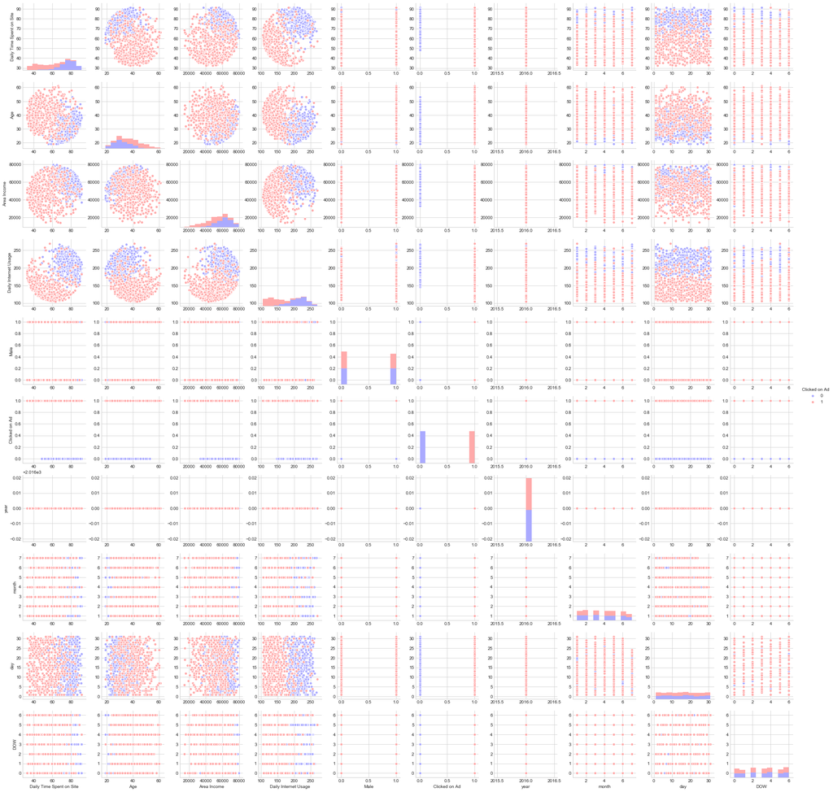

```python
sns.pairplot(data,hue='Clicked on Ad',palette='bwr')
```

### All of the visualizations above shows that there exists a non-linear relationship between variables and hence paves way for classification modelling

```python
from sklearn.model_selection import train_test_split

X = data[['Daily Time Spent on Site', 'Age', 'Area Income','Daily Internet Usage', 'Male']]
y = data['Clicked on Ad']

X_train, X_test, y_train, y_test = train_test_split(X, y, test_size=0.33, random_state=42)
```

# Logistic Regression Model

**logistic regression model on the training set.**

```python
from sklearn.linear_model import LogisticRegression

logmodel = LogisticRegression()
logmodel.fit(X_train,y_train)
```

```
LogisticRegression(C=1.0, class_weight=None, dual=False, fit_intercept=True,
          intercept_scaling=1, max_iter=100, multi_class='ovr', n_jobs=1,
          penalty='l2', random_state=None, solver='liblinear', tol=0.0001,
          verbose=0, warm_start=False)
```

## Predictions and Evaluations

```python
predictions = logmodel.predict(X_test)
```

**classification report**

```python
from sklearn.metrics import classification_report

print(classification_report(y_test,predictions))
```

```
             precision    recall  f1-score   support

          0       0.87      0.96      0.91       162
          1       0.96      0.86      0.91       168

avg / total       0.91      0.91      0.91       330
```

### From the above Classification report, we see that our model has an accuracy of 91% which means our model has performed well in predicting the dependent variable 'Clicked on Ad'.

### Note- No Model Tuning is shown here because this is a showcase of simple Logistic Regression and as this is the SKLEARN's Model, Parameter Regularization(L2 - Regularization by Default) is an automatic procedure for this model and thus can be said the the model is auto-tuned.